# Lab 3

Zeyad Awad

2022-10-25

```r
library(tidyverse)
library(openintro)
library(statsr)
library(broom)
```

### Exercise 1

The dimensions of the dataset are 1458 rows x 123 columns. Each row represents an observation of a country in the HFI in a specific year.

```r
dim(hfi)
```

```
## [1] 1458  123
```

### Exercise 2

```r
hfi_2016 <- hfi %>%
  filter(year == "2016") %>%
  select(pf_expression_control, pf_score, year, countries, hf_score, pf_ss)
```

### Exercise 3

I would use a scatter plot to display the relationship between these two variables. The relationship looks linear. Hence, predicting the pf_score given pf_expression_control is possible if we use a linear model.

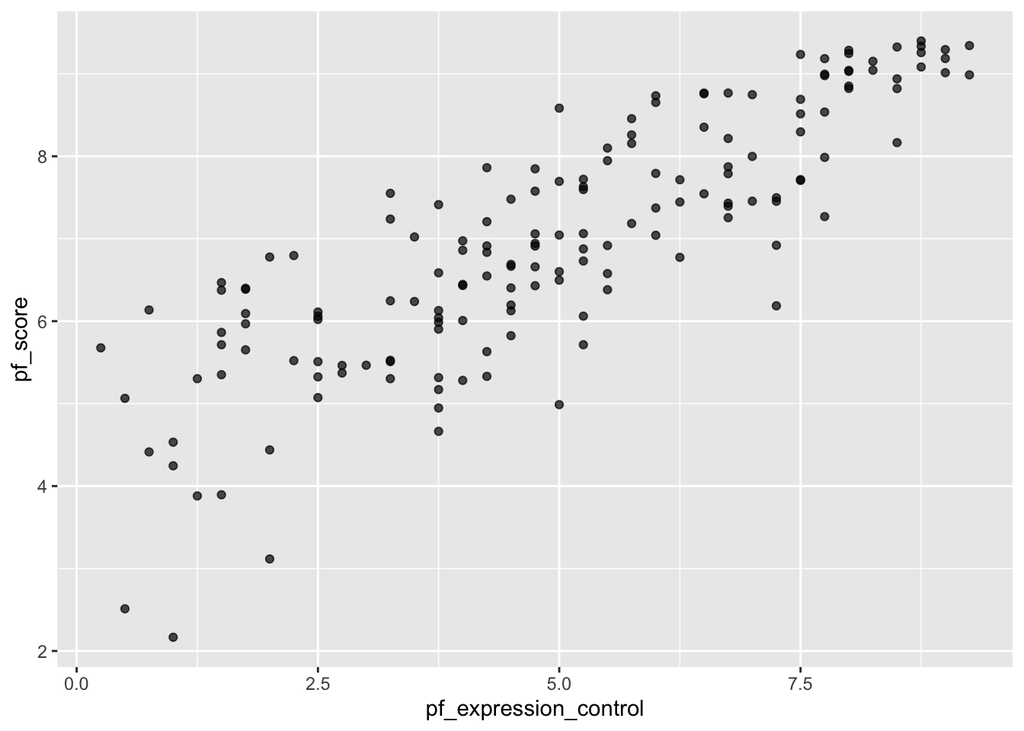

```r
ggplot(data=hfi_2016, aes(x = pf_expression_control, y = pf_score))+
  geom_point(alpha=0.7)
```

### Exercise 4

As depicted by the scatter plot in exercise 3 and the table below, there is a positive, strong correlation between these two variables. Additionally, there appears to be some outliers in the bottom left area of the graph.

```r
hfi_2016 %>%
  summarise(correlation = cor(pf_expression_control, pf_score))
```

```
## # A tibble: 1 × 1
##   correlation
##         <dbl>
## 1       0.845
```

### Exercise 5

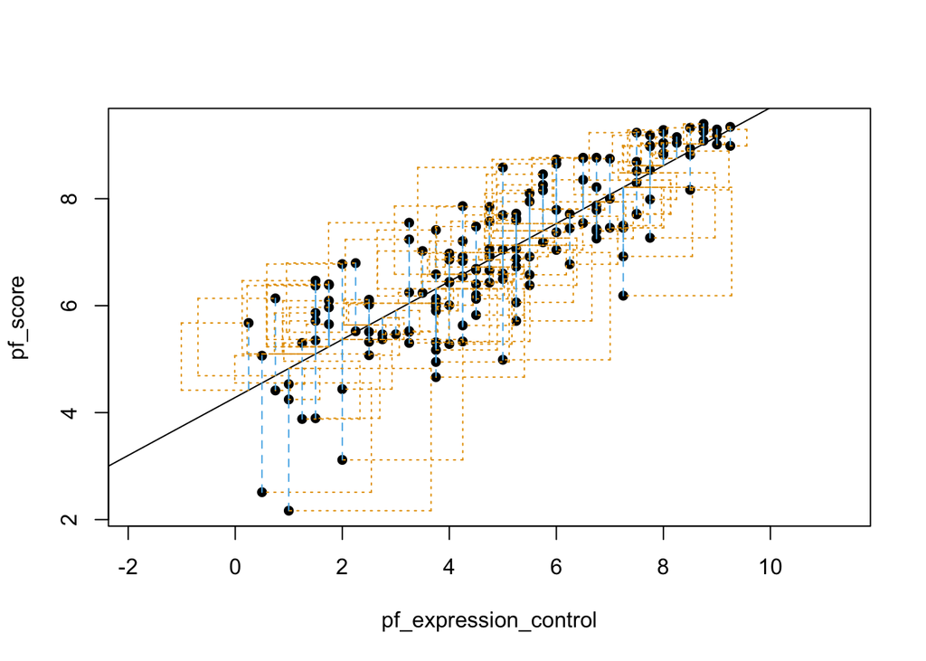

```
## Click two points to make a line.

## Call:
## lm(formula = y ~ x, data = pts)
##
## Coefficients:
## (Intercept)            x
##      4.2838       0.5418
##
## Sum of Squares:  102.213
```

```r
plot_ss(x = pf_expression_control, y = pf_score, data = hfi_2016, showSquares = TRUE)
```

### Exercise 6

hf_score = 5.053396 + 0.368432 * pf_expression_control. The slope tells us that for every unit increase in pf_expression_control, we expect, on average, a 0.368432 increase in a country’s total human freedom score. In a nutshell, the less the political pressure on the media content, the higher the human freedom score.

```r
m1 <- lm(hf_score ~ pf_expression_control, data = hfi_2016)
tidy(m1)
```

```
## # A tibble: 2 × 5
##   term                  estimate std.error statistic  p.value
##   <chr>                    <dbl>     <dbl>     <dbl>    <dbl>
## 1 (Intercept)              5.05     0.123       41.1 5.97e-87
## 2 pf_expression_control    0.368    0.0224      16.5 2.73e-36
```

```r
glance(m1)
```

```
## # A tibble: 1 × 12
##   r.squared adj.r.squa…¹ sigma stati…²  p.value    df logLik   AIC   BIC devia…³
##       <dbl>        <dbl> <dbl>   <dbl>    <dbl> <dbl>  <dbl> <dbl> <dbl>   <dbl>
## 1     0.629        0.627 0.660    271. 2.73e-36     1  -161.  329.  338.    69.6
## # … with 2 more variables: df.residual <int>, nobs <int>, and abbreviated
## #   variable names ¹adj.r.squared, ²statistic, ³deviance
```

### Exercise 7

From the regression line, one could depict that for a country with a pf_expression_control of 3, their personal freedom score is predicted to be 5.906 (see table 3). However, the actual observation for this pf_expression_control value has a pf_score of 5.465632 (see table 2). Hence, this is an overestimate. The residual is -0.440368.

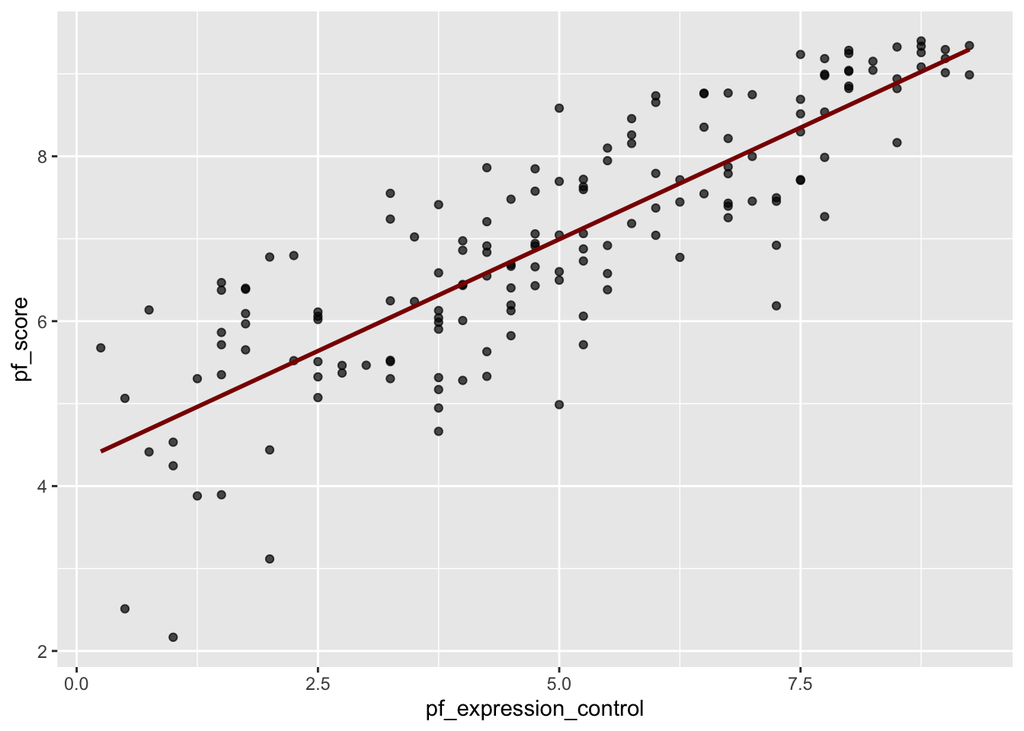

```r
ggplot(data = hfi_2016, aes(x = pf_expression_control, y = pf_score)) +
  geom_point(alpha=0.7) +
  geom_smooth(method = "lm", se = FALSE, formula = y ~ x, color = "darkred")
```

```r
hfi_2016 %>%
  filter(pf_expression_control == 3) %>%
  select(pf_expression_control, pf_score)
```

```
## # A tibble: 1 × 2
##   pf_expression_control pf_score
##                   <dbl>    <dbl>
## 1                     3     5.47
```

```r
4.28+0.542*3
```

```
## [1] 5.906
```

### Exercise 8

The appears to be no pattern in the residuals plot; they are scattered. This is an indicator that the two variables have a linear relationship.

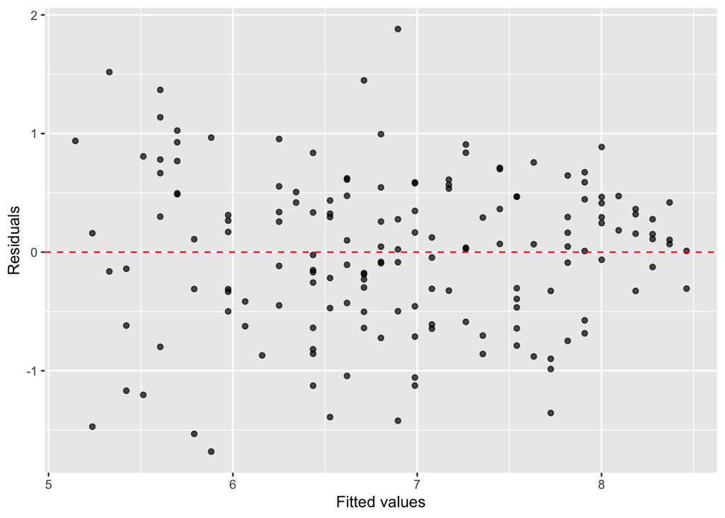

```r
m1_aug <- augment(m1)
ggplot(data = m1_aug, aes(x = .fitted, y = .resid)) +
  geom_point(alpha=0.7) +
  geom_hline(yintercept = 0, linetype = "dashed", color = "red") +
  xlab("Fitted values") +
  ylab("Residuals")
```

### Exercise 9

Based on the histogram, the residuals are roughly normal-distributed - there is a little left-skewness that makes it not “perfectly” normal-distributed. Hence, the nearly-normal residual condition is not violated.

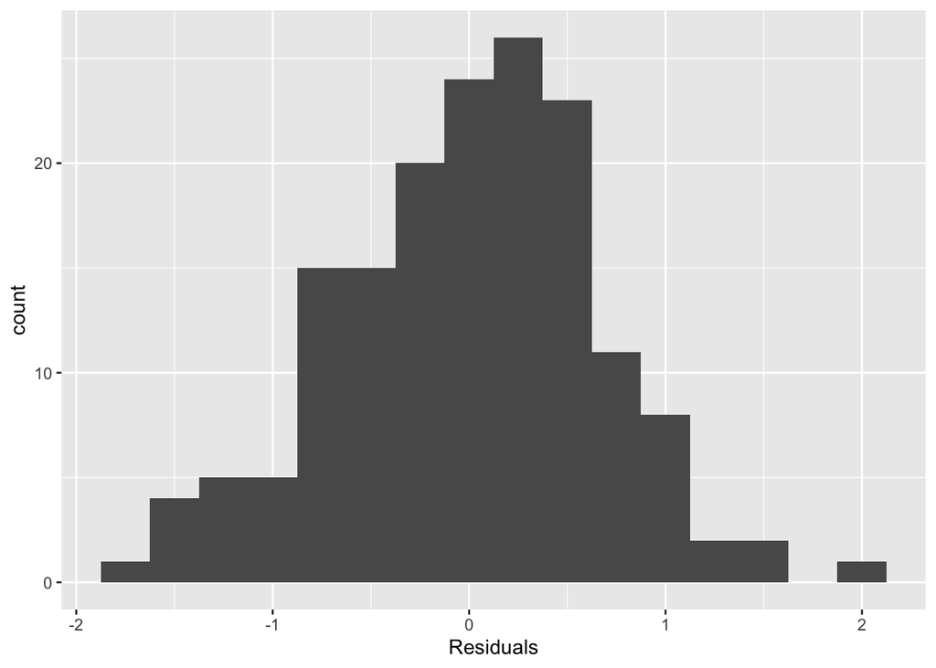

```r
ggplot(data = m1_aug, aes(x = .resid)) +
  geom_histogram(binwidth = 0.25) +
  xlab("Residuals")
```

### Exercise 10

Based on the residuals vs fitted-values plot, there appears to be roughly constant variability, ie., no “major” fanning in or out. Hence, the constant variability condition is not violated.

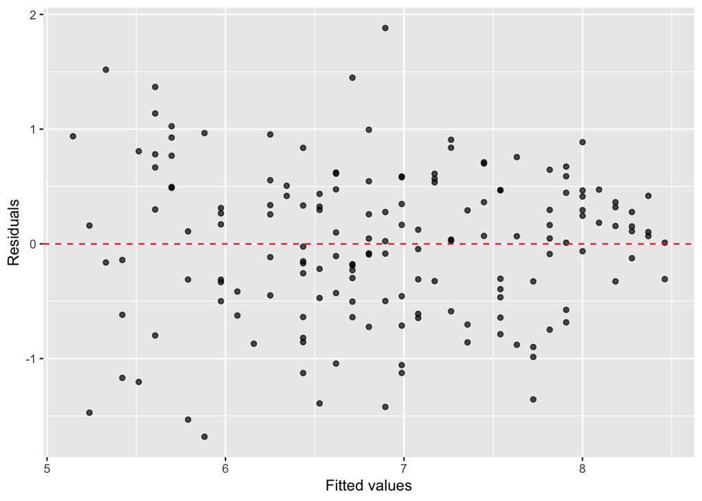

```r
m1_aug <- augment(m1)
ggplot(data = m1_aug, aes(x = .fitted, y = .resid)) +
  geom_point(alpha=0.7) +
  geom_hline(yintercept = 0, linetype = "dashed", color = "red") +
  xlab("Fitted values") +
  ylab("Residuals")
```

…